# Home Field Advantage

### October 4, 2021

# Introduction

Home-field advantage is something that we hear all across sports, but how does it actually help the home team? This advantage comes from the home team’s familiarity with their field, locker room, fans, and other factors that allow them to be more comfortable during the game. In most cases, the home team does have an advantage when playing on their own turf and we want to calculate how well having home-field advantage during a seven game series affects the outcome of the series. We will demonstrate using a World Series simulation between the New York Yankees and the Atlanta Braves to see how the odds change if it is played at Yankee Stadium in Bronx, NY or Truist Park in Atlanta, GA.

# Best-Of-7 Series

[output not shown]

# Assumptions

| Game Location | No Advantage | Advantage |
| --- | --- | --- |
| ATL | P<sub>B</sub> | P<sub>B</sub>^H = P<sub>B</sub> * 1.1 |
| NYY | P<sub>B</sub> | P<sub>B</sub>^A = 1 - (1 - P<sub>B</sub>) * 1.1 |

# Advantage vs. No Advantage

We have a dataset that shows us the 70 different outcomes for the 7 game series with a column for overall outcome for the Atlanta Braves. Here is a sample below:

```r
library(readr)
all_possible_world_series_outcomes <- read_csv("./all-possible-world-series-outcomes.csv")
```

```r
head(all_possible_world_series_outcomes)
```

```
## # A tibble: 6 × 8
##   game_1 game_2 game_3 game_4 game_5 game_6 game_7 overall_outcome
##   <chr>  <chr>  <chr>  <chr>  <chr>  <chr>  <chr>  <chr>
## 1 W      W      W      W      <NA>   <NA>   <NA>   W
## 2 W      W      W      L      W      <NA>   <NA>   W
## 3 W      W      L      W      W      <NA>   <NA>   W
## 4 W      L      W      W      W      <NA>   <NA>   W
## 5 L      W      W      W      W      <NA>   <NA>   W
## 6 W      W      W      L      L      W      <NA>   W
```

### Home-Field Advantage

```r
require(dplyr)
require(data.table)
```

To simulate a best-of-7 series where the New York Yankees have home-field advantage, we have the following code:

```r
# Get all possible outcomes
apo <- fread("./all-possible-world-series-outcomes.csv")

# Home field indicator
hfi <- c(0,0,1,1,1,0,0) #{NYC, NYC, ATL, ATL, ATL, NYC, NYC}

# P_B
pb <- 0.55
advantage_multiplier <- 1.1 # Set = 1 for no advantage
pbh <- 0.55*advantage_multiplier
pba <- 1 - (1 - 0.55)*advantage_multiplier

# Calculate the probability of each possible outcome
apo[, p := NA_real_] # Initialize new column in apo to store prob
for(i in 1:nrow(apo)){
  prob_game <- rep(1, 7)
  for(j in 1:7){
    p_win <- ifelse(hfi[j], pbh, pba)
    prob_game[j] <- case_when(
        apo[i,j,with=FALSE] == "W" ~ p_win
      , apo[i,j,with=FALSE] == "L" ~ 1 - p_win
      , TRUE ~ 1
    )
  }
  apo[i, p := prod(prob_game)] # Data.table syntax
}

# Sanity check: does sum(p) == 1?
apo[, sum(p)] # This is data.table notation
```

```
## [1] 1
```

```r
# Probability of overall World Series outcomes
apo[, sum(p), overall_outcome]
```

```
##    overall_outcome       V1
## 1:               W 0.604221
## 2:               L 0.395779
```

In the Code above we first need to read in the dataset and load in the required packages. We now can define a new variable *hfi* to be the home field indicator with a *1* representing a home game and a *0* for an away game for the Atlanta Braves (sequence of 0,0,1,1,1,0,0). Next, we must set the probabilities for each team and the weighted value (10%) for having a home-field advantage. *pbh* is the probability of a win that is set at 0.55, *pbh* represents the Braves’ home-field advantage and *pba* represents the Yankees’ home-field advantage. Now we calculate the probability of each possible outcome and will do that with a loop. After ensuring that we touched on every possible way a best-of-7 series can go, our output shows us that, with a 0.55 probability of winning game with a 10% boost for home-field advantage, the Atlanta Braves have a 0.604 or 60.4% chance of winning the series.

### No Home-Field Advantage

Under the assumption that P<sub>B</sub> = 0.55 for the Braves to win any given game, we will simply calculate the odds that the Braves win 4 games before losing 4.

```r
noAdv <- pnbinom(3,4,0.55)
noAdv
```

```
## [1] 0.6082878
```

With no home-field advantage and a probability of winning any given game at P<sub>B</sub> = 0.55, the Atlanta Braves have a 0.608 or 60.8% chance of beating the New York Yankees in a best-of-7 series.

### Difference

```r
# From code chunk above
wins <- apo[overall_outcome=="W"]
yesAdv <- sum(wins$p)

yesAdv - noAdv
```

```
## [1] -0.004066825
```

From our findings above, the Atlanta Braves chances of winning the World Series when home-field advantage is in the Yankees’ favor decreases by 0.004066825.

# Simulation

What we calculated above was done through the true probabilities of each given outcome for the 7 game series, but we would like to run simulations to test these the home-field advantage theory. We will take the same probabilities we set for each game with and without the boost from having home-field advantage and see how many series the Atlanta Braves win with the New York Yankees having 4 home games during the series.

### Home-Field Advantage

```r
# Home field indicator
hfi2 <- c(0,0,1,1,1,0,0) #{NYC, NYC, ATL, ATL, ATL, NYC, NYC}

# P_B
pb <- 0.55
advantage_multiplier <- 1.1
pbh <- 0.55*advantage_multiplier
pba <- 1 - (1 - 0.55)*advantage_multiplier

# Simulation
series <- rep(NA, 10000)
for (i in 1:10000) {
  game <- rep(NA, 7)
  for (j in 1:7) {
    win <- ifelse(hfi2[j], pbh, pba)
    game[j] = rbinom(1, 1, win)
    if (sum(game, na.rm = TRUE) == 4) {
      series[i] = 'W'
      break
      }
    else if (length(game[which(game == 0)]) == 4) {
      series[i] = "L"
      break
      }
    else
      next
  }
}

simYesAdv <- mean(series == 'W')
simYesAdv
```

```
## [1] 0.6004
```

I decided to run the simulation 10,000 times and when home-field advantage is factored into each game of the World Series, the Atlanta Braves have around a 59% to 60% chance of beating the New York Yankees.

### No Home-Field Advantage

```r
# Home field indicator
hfi2 <- c(0,0,1,1,1,0,0) #{NYC, NYC, ATL, ATL, ATL, NYC, NYC}

# P_B
pb <- 0.55
advantage_multiplier2 <- 1
pbh <- 0.55*advantage_multiplier2
pba <- 1 - (1 - 0.55)*advantage_multiplier2

# Simulation
series <- rep(NA, 10000)
for (i in 1:10000) {
  game <- rep(NA, 7)
  for (j in 1:7) {
    win <- ifelse(hfi2[j], pbh, pba)
    game[j] = rbinom(1, 1, win)
    if (sum(game, na.rm = TRUE) == 4) {
      series[i] = 'W'
      break
      }
    else if (length(game[which(game == 0)]) == 4) {
      series[i] = "L"
      break
      }
    else
      next
  }
}

simNoAdv <- mean(series == 'W')
simNoAdv
```

```
## [1] 0.6172
```

### Difference

```r
simYesAdv - simNoAdv
```

```
## [1] -0.0168
```

# Absolute and Relative Error

Relative error is defined as the absolute value of the observed probability we got from the simulation ($\hat{p}$) minus the actual probability and then divided by the actual probability. Relative probability can be better explained as the percent difference in actual vs. observed ((new-old)/old)x100. So for relative probability, we want to see, in percent terms, how far off our $\hat{p}$ is from the actual probability as replicates increase. Absolute error is more easily understood than relative error. It is simply the absolute value of the difference of our observed probability from the simulations and the true probability. With this value, we want to see how far our observed probability is from its true probability.

| Error | Description |
| --- | --- |
| abs_error | \|$\hat{p}$ - p\| |
| rel_error | \|$\hat{p}$ - p\| / p |

### Home-Field Advantage

#### Relative Error

```r
relErrorYesAdv <- abs(simYesAdv - yesAdv) / yesAdv
relErrorYesAdv
```

```
## [1] 0.006323798
```

#### Absolute Error

```r
absErrorYesAdv <- abs(simYesAdv - yesAdv)
absErrorYesAdv
```

```
## [1] 0.003820972
```

### No Home-Field Advantage

#### Relative Error

```r
relErrorNoAdv <- abs(simNoAdv - noAdv) / noAdv
relErrorNoAdv
```

```
## [1] 0.01465129
```

#### Absolute Error

```r
absErrorNoAdv <- abs(simNoAdv - noAdv)
absErrorNoAdv
```

```
## [1] 0.008912203
```

# Difference in Probabilities Depending on P<sub>B</sub>

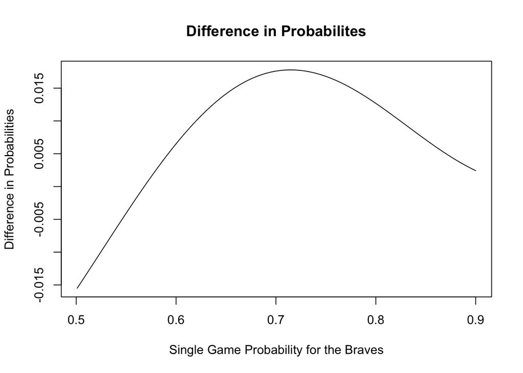

```r
pYesAdv <- rep(NA,400)
pNoAdv <- rep(NA,400)

for (q in 1:400){
apo <- fread("all-possible-world-series-outcomes.csv")

# Home field indicator
hfi <- c(0,0,1,1,1,0,0) #{NYC, NYC, ATL, ATL, ATL, NYC, NYC}

# P_B
pb <- 0.5+0.001*q
advantage_multiplier <- 1.1
pbh <- pb*advantage_multiplier
pba <- 1 - (1 - pb)*advantage_multiplier

# Calculate the probability of each possible outcome
apo[, p := NA_real_] # Initialize new column in apo to store prob
for(i in 1:nrow(apo)){
  prob_game <- rep(1, 7)
  for(j in 1:7){
    p_win <- ifelse(hfi[j], pbh, pba)
    prob_game[j] <- case_when(
        apo[i,j,with=FALSE] == "W" ~ p_win
      , apo[i,j,with=FALSE] == "L" ~ 1 - p_win
      , TRUE ~ 1
    )
  }
  apo[i, p := prod(prob_game)] # Data.table syntax
}

# Probability of overall World Series outcomes
apo[, sum(p), by=overall_outcome]
wins2 <- apo[overall_outcome=="W"]
pYesAdv[q]=sum(wins2$p)
pNoAdv[q]=pnbinom(3,4,0.5+0.001*q)
}

plot(seq(0.501,0.9,0.001),
     pYesAdv-pNoAdv,
     type='l',
     main="Difference in Probabilites",
     xlab='Single Game Probability for the Braves',
     ylab='Difference in Probabilities')
```

As we see from the plot above, the difference in probabilities is greatest when the single game probability (*P<sub>B</sub>*) is around 0.7 for the Atlanta Braves. This difference turns from negative to positive between 0.55 and 0.6, which means that this marker signals the tipping point where the home-field advantage becomes a significant factor in how the series will turn out for the Atlanta Braves.

# Difference in Probabilities Depending on Advantage Factor

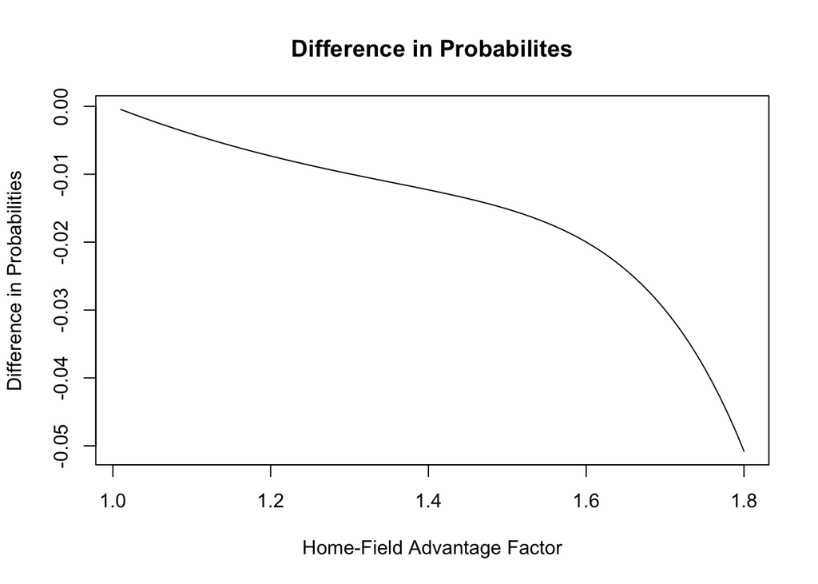

```r
pYesAdv2 <- rep(NA,80)
pNoAdv2 <- rep(NA,80)

for (q in 1:80){
apo <- fread("all-possible-world-series-outcomes.csv")

# Home field indicator
hfi <- c(0,0,1,1,1,0,0) #{NYC, NYC, ATL, ATL, ATL, NYC, NYC}

# P_B
pb <- 0.55
advantage_multiplier <- 1 + 0.01 * q
pbh <- pb*advantage_multiplier
pba <- 1 - (1 - pb)*advantage_multiplier

# Calculate the probability of each possible outcome
apo[, p := NA_real_] # Initialize new column in apo to store prob
for(i in 1:nrow(apo)){
  prob_game <- rep(1, 7)
  for(j in 1:7){
    p_win <- ifelse(hfi[j], pbh, pba)
    prob_game[j] <- case_when(
        apo[i,j,with=FALSE] == "W" ~ p_win
      , apo[i,j,with=FALSE] == "L" ~ 1 - p_win
      , TRUE ~ 1
    )
  }
  apo[i, p := prod(prob_game)] # Data.table syntax
}

# Probability of overall World Series outcomes
apo[, sum(p), by=overall_outcome]
wins3 <- apo[overall_outcome=="W"]
pYesAdv2[q]=sum(wins3$p)
pNoAdv2[q]=pnbinom(3,4,0.55)
}

plot(seq(1.01,1.8,0.01),
     pYesAdv2-pNoAdv2,
     type='l',
     main="Difference in Probabilites",
     xlab='Home-Field Advantage Factor',
     ylab='Difference in Probabilities')
```

This graph shows us that with the New York Yankees having home-field advantage in the World Series over the Braves, with 4 home games compared to 3, the advantage factor plays a huge role in the probability of winning the series. Even when P<sub>B</sub> = 0.55 for the Braves for any given game, when the home-field advantage factor gets to be too high, the single game advantage does not matter. This tipping point happens immediately and starts to flip the advantage to the New York Yankees.